# Project 2: Data Mining, Classification, Prediction

SDS322E

# Mining, Classification, Prediction

## Deanna Mendoza dfm692

### Introduction

*I am doing this Project over malignant melanoma- a form of skin cancer that develops in the melanocytes- and the survival rate after patients have their tumors removed. There are 7 variables- time, status, sex, age, year, thickness, and ulcer. There are two binary variables, sex (1 = male, 0 = female) and ulcer (1 = present, 0 = absent). The status variable indicates if the patient has died from melanoma (1), is alive (2), or has died from unrelated causes (3). I am interested in this data set because my family line is predisposed to cancer and it’s good to be knowledgeable and informed on these topics from actual research done.*

```r
library(tidyverse)

# install.packages('boot')
melanoma <- boot::melanoma
```

### Cluster Analysis

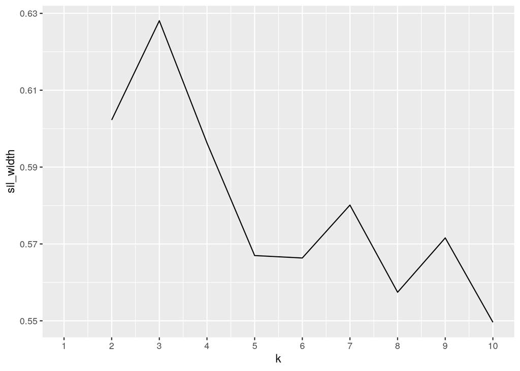

```r
library(cluster)

sil_width <- vector()  #empty vector to hold mean sil width
for (i in 2:10) {
    kms <- kmeans(melanoma, centers = i)  #compute k-means solution for each k
    sil <- silhouette(kms$cluster, dist(melanoma))  #get sil widths
    sil_width[i] <- mean(sil[, 3])  #take averages (higher is better)
}

ggplot() + geom_line(aes(x = 1:10, y = sil_width)) + scale_x_continuous(name = "k",
    breaks = 1:10)
```

```r
melanoma_pam <- melanoma %>% pam(k = 2)
melanoma_pam
```

```
## Medoids:
##      ID time status sex age year thickness ulcer
## 70   70 1678      2   0  59 1973      1.29     0
## 172 172 3383      2   0  43 1968      0.32     0
## Clustering vector:
##   1   2   3   4   5   6   7   8   9  10  11  12  13  14  15  16  17  18  19  20
##   1   1   1   1   1   1   1   1   1   1   1   1   1   1   1   1   1   1   1   1
##  21  22  23  24  25  26  27  28  29  30  31  32  33  34  35  36  37  38  39  40
##   1   1   1   1   1   1   1   1   1   1   1   1   1   1   1   1   1   1   1   1
##  41  42  43  44  45  46  47  48  49  50  51  52  53  54  55  56  57  58  59  60
##   1   1   1   1   1   1   1   1   1   1   1   1   1   1   1   1   1   1   1   1
##  61  62  63  64  65  66  67  68  69  70  71  72  73  74  75  76  77  78  79  80
##   1   1   1   1   1   1   1   1   1   1   1   1   1   1   1   1   1   1   1   1
##  81  82  83  84  85  86  87  88  89  90  91  92  93  94  95  96  97  98  99 100
##   1   1   1   1   1   1   1   1   1   1   1   1   1   1   1   1   1   1   1   1
##  [ reached getOption("max.print") -- omitted 105 entries ]
## Objective function:
##    build     swap
## 547.2422 502.9046
##
## Available components:
##  [1] "medoids"    "id.med"     "clustering" "objective"  "isolation"
##  [6] "clusinfo"   "silinfo"    "diss"       "call"       "data"
```

```r
melanoma_pam$silinfo$avg.width
```

```
## [1] 0.6039837
```

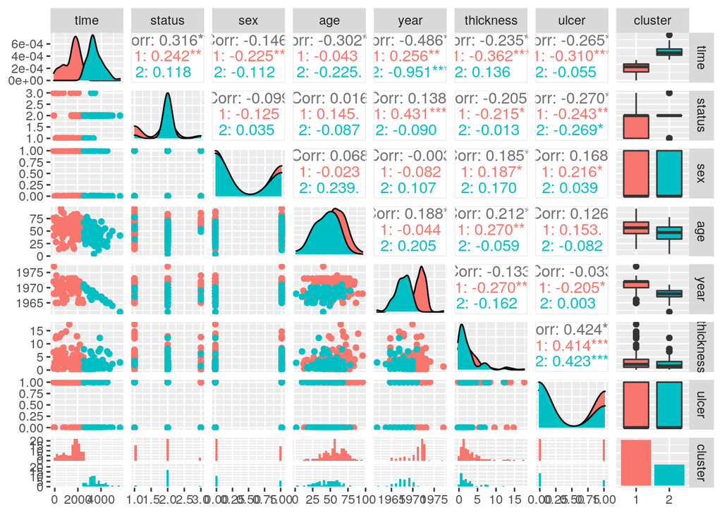

```r
library(GGally)

melanoma %>% mutate(cluster = as.factor(melanoma_pam$clustering)) %>%
    ggpairs(cols = 1:7, aes(color = cluster))
```

*Time has the greatest difference between the two clusters and has barely any overlapping. The variable age shows the most overlapping between the clusters. From visualizing the graphs, I assume that Cluster 1 (red) shows patients who were treated and survived for a shorter amount of time after the procedure and Cluster 2 (blue) has more survivors present to this day as you can see in the status variable clusters.*

### Dimensionality Reduction with PCA

```r
pca_melanoma <- princomp(melanoma, cor = T)

summary(pca_melanoma, loadings = "T")
```

```
## Importance of components:
##                           Comp.1    Comp.2    Comp.3    Comp.4    Comp.5
## Standard deviation     1.4438465 1.2097642 0.9862433 0.9513755 0.8449858
## Proportion of Variance 0.2978133 0.2090756 0.1389537 0.1293022 0.1020001
## Cumulative Proportion  0.2978133 0.5068889 0.6458426 0.7751448 0.8771449
##                            Comp.6     Comp.7
## Standard deviation     0.74069219 0.55799699
## Proportion of Variance 0.07837499 0.04448009
## Cumulative Proportion  0.95551991 1.00000000
##
## Loadings:
##           Comp.1 Comp.2 Comp.3 Comp.4 Comp.5 Comp.6 Comp.7
## time       0.514  0.367  0.294                0.188  0.692
## status     0.346 -0.298  0.655         0.470        -0.371
## sex       -0.268  0.134  0.279 -0.900 -0.135
## age       -0.325 -0.295  0.533  0.325 -0.566  0.299
## year      -0.173 -0.704 -0.141 -0.128  0.317         0.578
## thickness -0.445  0.317  0.319  0.215  0.181 -0.693  0.203
## ulcer     -0.460  0.274         0.142  0.554  0.621
```

```r
cormat2 <- pca_melanoma$scores %>% cor(use = "pair") %>% round(10)
cormat2
```

```
##        Comp.1 Comp.2 Comp.3 Comp.4 Comp.5 Comp.6 Comp.7
## Comp.1      1      0      0      0      0      0      0
## Comp.2      0      1      0      0      0      0      0
## Comp.3      0      0      1      0      0      0      0
## Comp.4      0      0      0      1      0      0      0
## Comp.5      0      0      0      0      1      0      0
## Comp.6      0      0      0      0      0      1      0
## Comp.7      0      0      0      0      0      0      1
```

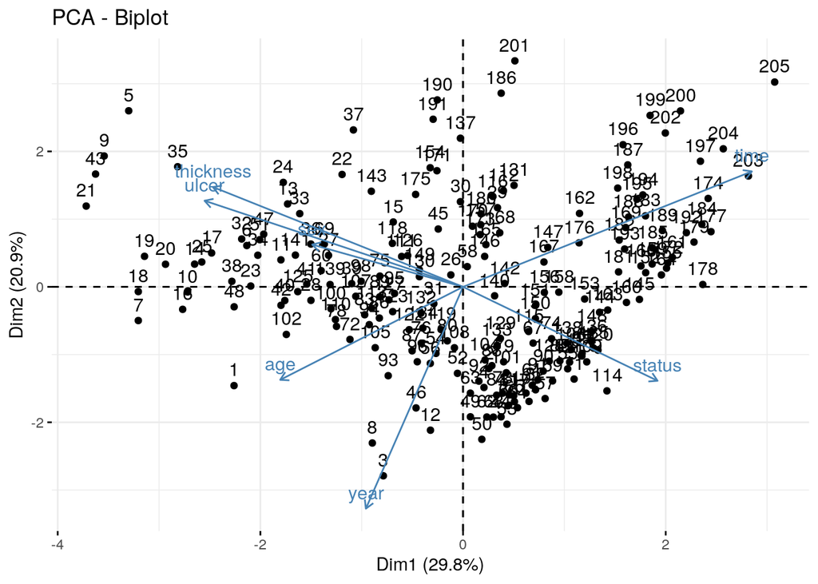

```r
library(factoextra)

fviz_pca_biplot(pca_melanoma)
```

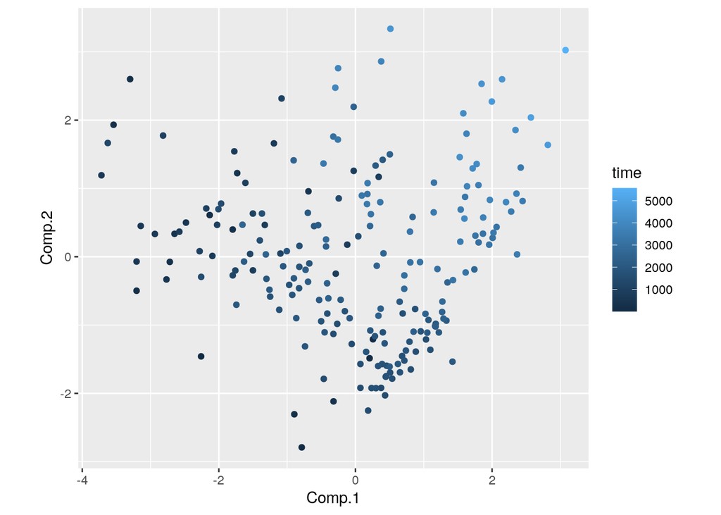

```r
tidycor2 <- pca_melanoma$scores %>% as.data.frame %>% mutate(time = melanoma$time)

tidycor2 %>% ggplot(aes(x = Comp.1, y = Comp.2, color = time)) +
    geom_point() + coord_fixed()
```

*For this data, we can keep 5 PCs to hit 87% of the total variance. For visualization purposes, I decided to graph PC1 and PC 2 in the last graph because they each have the greatest proportion of variance.*

*Comp. 1 has positive loadings for time and status, so this is a very general measure for how long a patient has survived after their procedure and if they are alive or dead. This component gives a quick glance of time vs. status. Comp. 2 has positive loadings for all variables besides status, age, and year. This is likely a component that focuses on only the ulcer itself and the gender of the individual. It focuses on the more binary variables present and gives a more clinical observation. Comp. 3 is positive for all variables but year and does not include ulcer. This component focuses on the age and survival of the individual.*

*If Comp. 1 is scored high on, the patient is likely dead from unrelated causes because they survived so long after the procedure,, but they were melanoma survivors. If Comp 2 is scored high on, the patient has a large ulceration present and a thick tumor that was removed. If Comp. 3 is scored high on, you are likely older and had a thick tumor present.*

*I notice that when the individual scores high on Comp. 1, they have a higher survival time and higher chance the patient outlived melanoma. This makes sense because Comp. 1 included a more general look at the status of patients in relation to time. The longer you survive the procedure, the more likely your cause of death will not be melanoma.*

### Linear Classifier

```r
melanoma_logical <- melanoma %>% select(-sex) %>% mutate(ulcer = as.logical(melanoma$ulcer))

logistic_fit <- glm(ulcer == "TRUE" ~ time + status + age + year +
    thickness, data = melanoma_logical, family = "binomial")

prob_reg <- predict(logistic_fit, type = "response")

class_diag(prob_reg, melanoma_logical$ulcer, positive = "TRUE")
```

```
##            acc   sens   spec    ppv     f1     ba    auc
## Metrics 0.7512 0.6222 0.8522 0.7671 0.6871 0.7372 0.8127
```

```r
fit <- glm(ulcer ~ ., data = melanoma_logical, family = "binomial")
probs <- predict(fit, type = "response")
table(truth = melanoma_logical$ulcer, predictions = probs > 0.5)
```

```
##        predictions
## truth   FALSE TRUE
##   FALSE    98   17
##   TRUE     34   56
```

```r
set.seed(150)
k = 10

data <- sample_frac(melanoma_logical)  #randomly order rows
folds <- rep(1:k, length.out = nrow(data))  #create folds

diags <- NULL

i = 1
for (i in 1:k) {
    train <- data[folds != i, ]
    test <- data[folds == i, ]
    truth <- test$ulcer

    # train model
    fit <- glm(ulcer == "TRUE" ~ time + status + age + year +
        thickness, data = train)
    coef(fit)

    # test model
    probs <- predict(fit, newdata = test, type = "response")

    diags <- rbind(diags, class_diag(probs, truth, positive = "TRUE"))
}

summarize_all(diags, mean)
```

```
##      acc    sens    spec     ppv      f1      ba     auc
## 1 0.7319 0.56811 0.86081 0.79737 0.63424 0.71446 0.79569
```

*There is a noticeable decrease in AUC (0.813 to 0.796) when predicting out of sample. There is a sign of overfitting because the AUC dropped in CV.*

### Non-Parametric Classifier

```r
library(caret)

fit <- knn3(ulcer ~ ., data = melanoma_logical)
probs <- predict(fit, newdata = melanoma_logical)[, 2]
class_diag(probs, melanoma_logical$ulcer, positive = "TRUE")
```

```
##            acc   sens   spec    ppv    f1     ba    auc
## Metrics 0.7463 0.6111 0.8522 0.7639 0.679 0.7316 0.8143
```

```r
table(truth = melanoma_logical$ulcer, predictions = probs > 0.5)
```

```
##        predictions
## truth   FALSE TRUE
##   FALSE    98   17
##   TRUE     35   55
```

```r
set.seed(150)
k = 10

data <- sample_frac(melanoma_logical)  #randomly order rows
folds <- rep(1:k, length.out = nrow(data))  #create folds

diags <- NULL

i = 1
for (i in 1:k) {
    train <- data[folds != i, ]
    test <- data[folds == i, ]
    truth <- test$ulcer

    # train model
    fit <- knn3(ulcer == "TRUE" ~ time + status + age + year +
        thickness, data = train, k = 5)
    coef(fit)

    # test model
    probs <- predict(fit, test)[, 2]

    diags <- rbind(diags, class_diag(probs, truth, positive = "TRUE"))
}

summarize_all(diags, mean)
```

```
##       acc    sens    spec     ppv      f1      ba     auc
## 1 0.56095 0.48264 0.64744 0.52046 0.47877 0.56504 0.66369
```

*There is a noticeable decrease in AUC (0.814 to 0.664) when predicting out of sample. There is a sign of overfitting because the AUC dropped in CV. Overall, I would say that the linear model performed much better than the non-parametric model because there was less overfitting present. There was a smaller decrease (0.017 vs. 0.150) in CV AUC with the linear model.*

### Regression/Numeric Prediction

```r
fit <- lm(thickness ~ ., data = melanoma_logical)  #predict mpg from all other variables
yhat <- predict(fit)

# cbind(yhat, y=melanoma_logical$thickness)

mean((melanoma_logical$thickness - yhat)^2)
```

```
## [1] 6.420423
```

```r
set.seed(1234)
k = 5  #choose number of folds
data <- melanoma_logical[sample(nrow(melanoma_logical)), ]  #randomly order rows
folds <- cut(seq(1:nrow(melanoma_logical)), breaks = k, labels = F)  #create folds
diags <- NULL
for (i in 1:k) {
    train <- data[folds != i, ]
    test <- data[folds == i, ]
    ## Fit linear regression model to training set
    fit <- lm(thickness ~ ., data = train)
    ## Get predictions/y-hats on test set (fold i)
    yhat <- predict(fit, newdata = test)
    ## Compute prediction error (MSE) for fold i
    diags <- mean((test$thickness - yhat)^2)
}
mean(diags)
```

```
## [1] 4.984817
```

*The MSE from the linear regression model and overall dataset is 6.42 and then 4.98 in cross validation. This is a good indicator that there is no overfitting present.*

### Python

```r
library(reticulate)
use_python("/usr/bin/python3")
plot <- import("matplotlib")
plot$use("Agg", force = TRUE)

x <- melanoma$time
y <- melanoma$status
```

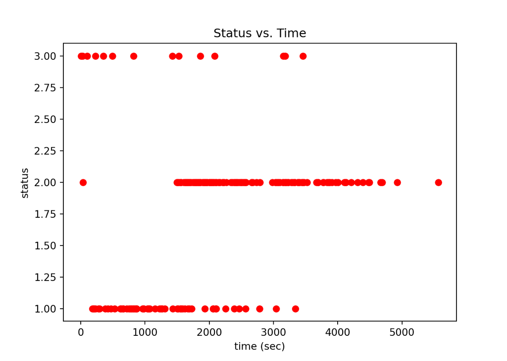

```python
import matplotlib.pyplot as plt

plt.scatter(r.x, r.y, color = "red")
plt.xlabel('time (sec)')
plt.ylabel('status')
plt.title('Status vs. Time')
plt.show()
```

```python
x =  12
y = 13
```

```r
z = py$x + py$y
print(paste("python x + python y = ", z))
```

```
## [1] "python x + python y =  25"
```

```r
head(x)
```

```
## [1]  10  30  35  99 185 204
```

```r
head(y)
```

```
## [1] 3 3 2 3 1 1
```

*In the first code chunk, I used R to establish the objects x and y from the `melanoma` dataset. Then in the python code chunk, I used ‘r.’ to share the r objects in the python chunk without importing the entire dataset.* *I then made a basic Status vs. Time plot in python and colored it red. At the end of the python code chunk, I established new objects that were the same name as the R objects.* *Then in the second R code chunk, I added the two objects, x and y, from the python chunk and printed the first couple of values from the R x and y to show that they are different values.*

### Concluding Remarks

Overall, I learned that there is a good relationship from the variables in the ‘melanoma’ dataset. You are able to use the variables in the dataset to predict the outcomes of the rest of the dataset. Personally, I found that it was interesting to use PCA and generate different PC’s to see how the data can be grouped to tell different aspects of the dataset.